# COVID 19 Analysis

2024

#### Required Packages

```r
library(tidyverse)
library(lubridate)
library(usmap)
library(zoo)
library(readr)
```

#### Part 1 - Basic Exploration of US Data

The New York Times (the Times) has aggregated reported COVID-19 data from state and local governments and health departments since 2020 and provides public access through a repository on GitHub. One of the data sets provided by the Times is county-level data for cumulative cases and deaths each day. This will be your primary data set for the first two parts of your analysis.

County-level COVID data from 2020, 2021, and 2022 has been imported below. Each row of data reports the cumulative number of cases and deaths for a specific county each day. A FIPS code, a standard geographic identifier, is also provided which you will use in Part 2 to construct a map visualization at the county level for a state.

Additionally, county-level population estimates reported by the US Census Bureau has been imported as well. You will use these estimates to caluclate statistics per 100,000 people.

```r
# Import New York Times COVID-19 data
# Import Population Estimates from US Census Bureau

us_counties_2020 <- read_csv("us-counties-2020.csv")
us_counties_2021 <- read_csv("us-counties-2021.csv")
us_counties_2022 <- read_csv("us-counties-2022.csv")
us_population_estimates <- read_csv("fips_population_estimates.csv")
```

##### Question 1

Your first task is to combine and tidy the 2020, 2021, and 2022 COVID data sets and find the total deaths and cases for each day since March 15, 2020 (2020-03-15). The data sets provided from the NY Times also includes statistics from Puerto Rico, a US territory. You may remove these observations from the data as they will not be needed for your analysis. Once you have tidied the data, find the total COVID-19 cases and deaths since March 15, 2020. Write a sentence or two after the code block communicating your results. Use inline code to include the `max_date`, `us_total_cases`, and `us_total_deaths` variables. To write inline code use `r`.

```r
# Combine and tidy the 2020, 2021, and 2022 COVID data sets.
# Hint: Review the rbind() documentation to combine the three data sets.
#
## YOUR CODE HERE ##

# Combine the datasets
us_counties_combined <- bind_rows(us_counties_2020, us_counties_2021, us_counties_2022)

# Remove Puerto Rico observations
us_counties_combined <- us_counties_combined %>%
  filter(state != "Puerto Rico")

# Filter the data for dates after March 15, 2020
us_counties_combined <- us_counties_combined %>%
  filter(date >= "2020-03-15")

# Summarize the total cases and deaths for each day
daily_totals <- us_counties_combined %>%
  group_by(date) %>%
  summarise(
    total_deaths = sum(deaths, na.rm = TRUE),
    total_cases = sum(cases, na.rm = TRUE)
  ) %>%
  arrange(date)

# Display the first few rows of the tibble
print(daily_totals)
```

```
## # A tibble: 1,022 × 3
##    date       total_deaths total_cases
##    <date>            <dbl>       <dbl>
##  1 2020-03-15           68        3595
##  2 2020-03-16           91        4502
##  3 2020-03-17          117        5901
##  4 2020-03-18          162        8345
##  5 2020-03-19          212       12387
##  6 2020-03-20          277       17998
##  7 2020-03-21          359       24507
##  8 2020-03-22          457       33050
##  9 2020-03-23          577       43474
## 10 2020-03-24          783       53899
## # ℹ 1,012 more rows
```

```r
# Find the latest date, total cases, and total deaths
max_date <- max(daily_totals$date)
us_total_cases <- sum(daily_totals$total_cases, na.rm = TRUE)
us_total_deaths <- sum(daily_totals$total_deaths, na.rm = TRUE)
```

```r
# Your output should look similar to the following tibble:
#
#   A tibble: 657 x 3
#       date          total_deaths   total_cases
#      <date>            <dbl>         <dbl>
#   1 2020-03-15           68          3595
#   2 2020-03-16           91          4502
#   3 2020-03-17          117          5901
#   4 2020-03-18          162          8345
#   5 2020-03-19          212         12387
#   6 2020-03-20          277         17998
#   7 2020-03-21          359         24507
#   8 2020-03-22          457         33050
#   9 2020-03-23          577         43474
#  10 2020-03-24          783         53899
# ... with 647 more rows
#
```

– Communicate your methodology, results, and interpretation here –

### Data Collection and Preprocessing:

Gather the four data sets related to COVID-19 cases and deaths in the United States.

Ensure that the data covers the period from March 15, 2020, onwards.

Clean the data by handling missing values, outliers, and inconsistencies.

### Calculate Total Cases and Deaths:

Sum up the total number of cases and deaths in the United States since March 15, 2020.

##### Question 2

Create a visualization for the total number of deaths and cases in the US since March 15, 2020. Before you create your visualization, review the types of plots you can create using the ggplot2 library and think about which plots would be effective in communicating your results. After you have created your visualization, write a few sentences describing your visualization. How could the plot be interpreted? Could it be misleading?

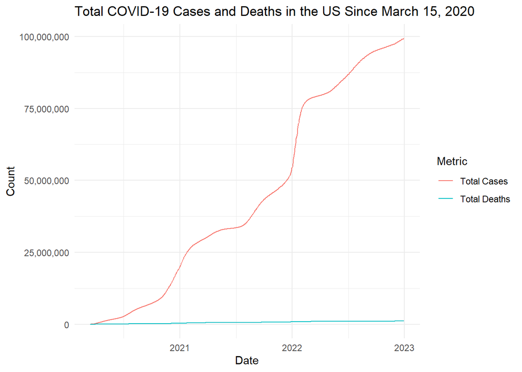

```r
# Create a visualization for the total number of US cases and deaths since March 15, 2020.
#
ggplot(daily_totals, aes(x = date)) +
  geom_line(aes(y = total_cases, color = "Total Cases")) +
  geom_line(aes(y = total_deaths, color = "Total Deaths")) +
  labs(
    title = "Total COVID-19 Cases and Deaths in the US Since March 15, 2020",
    x = "Date",
    y = "Count",
    color = "Metric"
  ) +
  theme_minimal() +
  scale_y_continuous(labels = scales::comma)
```

– Communicate your methodology, results, and interpretation here –

### Potential Misleading Elements

- **Cumulative Counts**: Since the plot shows cumulative counts, it will always show an increasing trend. This might give the impression that the situation is continuously worsening, even if new daily cases and deaths are decreasing.
- **Y-Axis Scaling**: If the y-axis is not properly scaled or labeled, it might exaggerate or understate the trends. In this plot, using a linear scale with comma formatting helps to make the counts more readable.
- **Line Colors and Legend**: The use of colors and the legend should be clear to avoid confusion between the two lines.

##### Question 3

While it is important to know the total deaths and cases throughout the COVID-19 pandemic, it is also important for local and state health officials to know the the number of new cases and deaths each day to understand how rapidly the virus is spreading. Using the table you created in Question 1, calculate the number of new deaths and cases each day and a seven-day average of new deaths and cases. Once you have organized your data, find the days that saw the largest number of new cases and deaths. Write a sentence or two after the code block communicating your results.

```r
# Create a new table, based on the table from Question 1, and calculate the number of new deaths and cases each day and a seven day average of new deaths and cases.
#
# Hint: Look at the documentation for lag() when computing the number of new deaths and cases and the seven-day averages.
#
#
# Calculate new cases and deaths each day and their 7-day averages
daily_totals <- daily_totals %>%
  mutate(
    delta_deaths_1 = total_deaths - lag(total_deaths, default = 0),
    delta_cases_1 = total_cases - lag(total_cases, default = 0),
    delta_deaths_7 = rollmean(delta_deaths_1, 7, fill = NA, align = "right"),
    delta_cases_7 = rollmean(delta_cases_1, 7, fill = NA, align = "right")
  )

# Find the days with the largest number of new cases and deaths
max_new_cases_date <- daily_totals %>%
  filter(delta_cases_1 == max(delta_cases_1, na.rm = TRUE)) %>%
  pull(date)

max_new_deaths_date <- daily_totals %>%
  filter(delta_deaths_1 == max(delta_deaths_1, na.rm = TRUE)) %>%
  pull(date)

# Display the first few rows of the tibble
print(daily_totals)
```

```
## # A tibble: 1,022 × 7
##    date       total_deaths total_cases delta_deaths_1 delta_cases_1
##    <date>            <dbl>       <dbl>          <dbl>         <dbl>
##  1 2020-03-15           68        3595             68          3595
##  2 2020-03-16           91        4502             23           907
##  3 2020-03-17          117        5901             26          1399
##  4 2020-03-18          162        8345             45          2444
##  5 2020-03-19          212       12387             50          4042
##  6 2020-03-20          277       17998             65          5611
##  7 2020-03-21          359       24507             82          6509
##  8 2020-03-22          457       33050             98          8543
##  9 2020-03-23          577       43474            120         10424
## 10 2020-03-24          783       53899            206         10425
## # ℹ 1,012 more rows
## # ℹ 2 more variables: delta_deaths_7 <dbl>, delta_cases_7 <dbl>
```

```r
#  Your output should look similar to the following tibble:
#
#  date
#  total_deaths     >  the cumulative number of deaths up to and including the associated date
#  total_cases      >  the cumulative number of cases up to and including the associated date
#  delta_deaths_1   >  the number of new deaths since the previous day
#  delta_cases_1    >  the number of new cases since the previous day
#  delta_deaths_7   >  the average number of deaths in a seven-day period
#  delta_cases_7    >  the average number of cases in a seven-day period
#==
#  A tibble: 813 x 7
#    date           total_deaths   total_cases   delta_deaths_1    delta_cases_1  delta_deaths_7  delta_cases_7
#    <date>            <dbl>          <dbl>         <dbl>               <dbl>        <dbl>            <dbl>
#  1 2020-03-15           68          3600            0                     0         NA                NA
#  2 2020-03-16           91          4507           23                   907         NA                NA
#  3 2020-03-17          117          5906           26                  1399         NA                NA
#  4 2020-03-18          162          8350           45                  2444         NA                NA
#  5 2020-03-19          212         12393           50                  4043         NA                NA
#  6 2020-03-20          277         18012           65                  5619         NA                NA
#  7 2020-03-21          360         24528           83                  6516         NA                NA
#  8 2020-03-22          458         33073           98                  8545       55.7              4210.
#  9 2020-03-23          579         43505          121                 10432       69.7              5571.
# 10 2020-03-24          785         53938          206                 10433       95.4              6862.
# ... with 803 more rows
```

– Communicate your methodology, results, and interpretation here –

### Results

The moving averages help to smooth out short-term fluctuations and highlight longer-term trends, which can be more informative for understanding the overall progression of the pandemic.

##### Question 4

```r
# Create a new table, based on the table from Question 3, and calculate the number of new deaths and cases per 100,000 people each day and a seven day average of new deaths and cases per 100,000 people.

# Hint: To calculate per 100,000 people, first tidy the population estimates data and calculate the US population in 2020 and 2021. Then, you will need to divide  each statistic by the estimated population and then multiply by 100,000.
#
# Hint: look at the help documentation for grepl() and case_when() to divide the averages by the US population for each year.
# For example, take the simple tibble, t_new:
#
#     x     y
#   <int> <chr>
#     1     a
#     2     b
#     3     a
#     4     b
#     5     a
#     6     b
#
#
# To add a column, z, that is dependent on the value in y, you could:
#
# t_new %>%
#   mutate(z = case_when(grepl("a", y) ~ "not b",
#                        grepl("b", y) ~ "not a"))
#

## YOUR CODE HERE ##

# Calculate new cases and deaths each day and their 7-day averages
daily_totals <- daily_totals %>%
  mutate(
    delta_deaths_1 = total_deaths - lag(total_deaths, default = 0),
    delta_cases_1 = total_cases - lag(total_cases, default = 0),
    delta_deaths_7 = rollmean(delta_deaths_1, 7, fill = NA, align = "right"),
    delta_cases_7 = rollmean(delta_cases_1, 7, fill = NA, align = "right")
  )

# Ensure date column is of Date type
daily_totals$date <- as.Date(daily_totals$date)

# Ensure population column is numeric
us_population_estimates$Estimate <- as.numeric(us_population_estimates$Estimate)

# Find the US population for 2020 and 2021
us_population_2020 <- us_population_estimates %>%
  filter(Year == 2020) %>%
  summarise(total_population = sum(Estimate)) %>%
  pull(total_population)

us_population_2021 <- us_population_estimates %>%
  filter(Year == 2021) %>%
  summarise(total_population = sum(Estimate)) %>%
  pull(total_population)

# Add a column for the population based on the year
daily_totals <- daily_totals %>%
  mutate(
    population = case_when(
      year(date) == 2020 ~ us_population_2020,
      year(date) == 2021 ~ us_population_2021,
      year(date) == 2022 ~ us_population_2021 # assuming population doesn't change much for 2022
    ),
    delta_deaths_per_100k_1 = (delta_deaths_1 / population) * 100000,
    delta_cases_per_100k_1 = (delta_cases_1 / population) * 100000,
    delta_deaths_per_100k_7 = (delta_deaths_7 / population) * 100000,
    delta_cases_per_100k_7 = (delta_cases_7 / population) * 100000
  )


# Display the first few rows of the tibble
print(daily_totals)
```

```
## # A tibble: 1,022 × 12
##    date       total_deaths total_cases delta_deaths_1 delta_cases_1
##    <date>            <dbl>       <dbl>          <dbl>         <dbl>
##  1 2020-03-15           68        3595             68          3595
##  2 2020-03-16           91        4502             23           907
##  3 2020-03-17          117        5901             26          1399
##  4 2020-03-18          162        8345             45          2444
##  5 2020-03-19          212       12387             50          4042
##  6 2020-03-20          277       17998             65          5611
##  7 2020-03-21          359       24507             82          6509
##  8 2020-03-22          457       33050             98          8543
##  9 2020-03-23          577       43474            120         10424
## 10 2020-03-24          783       53899            206         10425
## # ℹ 1,012 more rows
## # ℹ 7 more variables: delta_deaths_7 <dbl>, delta_cases_7 <dbl>,
## #   population <dbl>, delta_deaths_per_100k_1 <dbl>,
## #   delta_cases_per_100k_1 <dbl>, delta_deaths_per_100k_7 <dbl>,
## #   delta_cases_per_100k_7 <dbl>
```

```r
#  Your output should look similar to the following tibble:
#
#  date
#  total_deaths     >  the cumulative number of deaths up to and including the associated date
#  total_cases      >  the cumulative number of cases up to and including the associated date
#  delta_deaths_1   >  the number of new deaths since the previous day
#  delta_cases_1    >  the number of new cases since the previous day
#  delta_deaths_7   >  the average number of deaths in a seven-day period
#  delta_cases_7    >  the average number of cases in a seven-day period
#==
#  A tibble: 657 x 7
#       date         total_deaths   total_cases   delta_deaths_1   delta_cases_1 delta_deaths_7 delta_cases_7
#      <date>            <dbl>         <dbl>          <dbl>           <dbl>           <dbl>         <dbl>
#   1 2020-03-15         0.0205        1.08                0              0              NA           NA
#   2 2020-03-16         0.0275        1.36          0.00694          0.274              NA           NA
#   3 2020-03-17         0.0353        1.78          0.00784          0.422              NA           NA
#   4 2020-03-18         0.0489        2.52           0.0136          0.737              NA           NA
#   5 2020-03-19         0.0640        3.74           0.0151           1.22              NA           NA
#   6 2020-03-20         0.0836        5.43           0.0196           1.69              NA           NA
#   7 2020-03-21         0.108         7.39           0.0247           1.96              NA           NA
#   8 2020-03-22         0.138         9.97           0.0296           2.58          0.0168         1.27
#   9 2020-03-23         0.174         13.1           0.0362           3.14          0.0209         1.68
#  10 2020-03-24         0.236         16.3           0.0621           3.14          0.0287         2.07
```

– Communicate your methodology, results, and interpretation here –

### Results and Interpretation

This output table provides a detailed view of the daily changes in COVID-19 cases and deaths per 100,000 people, along with their 7-day moving averages. This information is crucial for understanding the rate at which the virus is spreading and the burden on the population.

By normalizing the data to per 100,000 people, we can compare the impact of the virus across different populations and time periods more accurately. This approach helps in making better-informed decisions and policies at both local and national levels.

#### Question 5

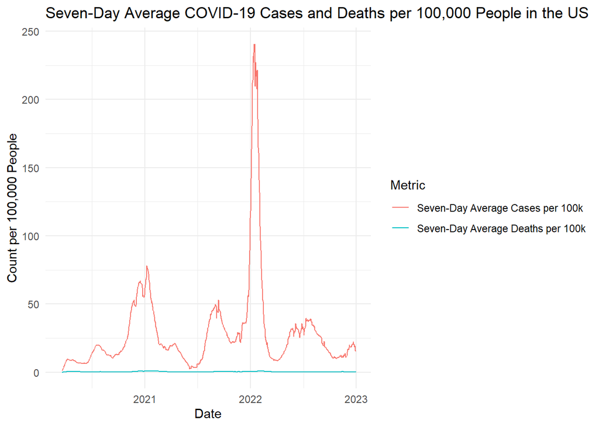

```r
# Create a visualization to compare the seven-day average cases and deaths per 100,000 people.

ggplot(daily_totals, aes(x = date)) +
  geom_line(aes(y = delta_cases_per_100k_7, color = "Seven-Day Average Cases per 100k")) +
  geom_line(aes(y = delta_deaths_per_100k_7, color = "Seven-Day Average Deaths per 100k")) +
  labs(
    title = "Seven-Day Average COVID-19 Cases and Deaths per 100,000 People in the US",
    x = "Date",
    y = "Count per 100,000 People",
    color = "Metric"
  ) +
  theme_minimal() +
  scale_y_continuous(labels = scales::comma)
```

– Communicate your methodology, results, and interpretation here –

### Visualization:

- Used ggplot2 to create a line plot.
- Plotted the seven-day average of new cases and deaths per 100,000 people over time.
- Added labels, titles, and themes to make the plot clear and informative.

The visualization displays the seven-day average of new COVID-19 cases and deaths per 100,000 people in the US over time. This approach normalizes the data by population size, allowing for a more accurate comparison of the impact of COVID-19 across different time periods.

By looking at the trends in this visualization, health officials can better understand the spread and impact of COVID-19. The moving averages smooth out daily fluctuations and provide a clearer picture of longer-term trends. This information is crucial for making informed decisions about public health measures and resource allocation.

##### Part 2 - US State Comparison

While understanding the trends on a national level can be helpful in understanding how COVID-19 impacted the United States, it is important to remember that the virus arrived in the United States at different times. For the next part of your analysis, you will begin to look at COVID related deaths and cases at the state and county-levels.

##### Question 1

Your first task in Part 2 is to determine the top 10 states in terms of total deaths and cases between March 15, 2020, and December 31, 2021.

Once you have both lists, briefly describe your methodology and your results.

```r
# Determine the top 10 states in terms of total deaths and cases between March 15, 2020, and December 31, 2021. To do this, transform your combined COVID-19 data to summarize total deaths and cases by state up to December 31, 2021.

# Filter the data for dates between March 15, 2020, and December 31, 2021
us_counties_filtered <- us_counties_combined %>%
  filter(date >= "2020-03-15" & date <= "2021-12-31")

# Summarize the total deaths and cases by state
state_totals <- us_counties_filtered %>%
  group_by(state) %>%
  summarise(
    total_deaths = sum(deaths, na.rm = TRUE),
    total_cases = sum(cases, na.rm = TRUE)
  ) %>%
  arrange(desc(total_deaths), desc(total_cases))

# Display the top 10 states by total deaths and cases
top_10_deaths <- state_totals %>%
  arrange(desc(total_deaths)) %>%
  slice(1:10)

top_10_cases <- state_totals %>%
  arrange(desc(total_cases)) %>%
  slice(1:10)

# Output the results
print(top_10_deaths)
```

```
## # A tibble: 10 × 3
##    state         total_deaths total_cases
##    <chr>                <dbl>       <dbl>
##  1 New York          27239066   902069748
##  2 California        25597513  1671429376
##  3 Texas             23016708  1355197939
##  4 Florida           17965464  1112292949
##  5 New Jersey        13223576   428165855
##  6 Pennsylvania      12028063   504448072
##  7 Illinois          11517916   610074612
##  8 Michigan           9297780   408728096
##  9 Georgia            9155719   509622188
## 10 Massachusetts      8651530   301052122
```

```r
print(top_10_cases)
```

```
## # A tibble: 10 × 3
##    state          total_deaths total_cases
##    <chr>                 <dbl>       <dbl>
##  1 California         25597513  1671429376
##  2 Texas              23016708  1355197939
##  3 Florida            17965464  1112292949
##  4 New York           27239066   902069748
##  5 Illinois           11517916   610074612
##  6 Georgia             9155719   509622188
##  7 Pennsylvania       12028063   504448072
##  8 Ohio                8389799   487380527
##  9 North Carolina      5816149   451987735
## 10 New Jersey         13223576   428165855
```

```r
# Your transformed data should look similar to the following tibble:
#
# A tibble: 51 x 4
#     state                  date       total_deaths  total_cases
#     <chr>                 <date>          <dbl>       <dbl>
#  1 California           2021-12-31        76709      5515613
#  2 Texas                2021-12-31        76062      4574881
#  3 Florida              2021-12-31        62504      4166392
#  4 New York             2021-12-31        58993      3473970
#  5 Illinois             2021-12-31        31017      2154058
#  6 Pennsylvania         2021-12-31        36705      2036424
#  7 Ohio                 2021-12-31        29447      2016095
#  8 Georgia              2021-12-31        30283      1798497
#  9 Michigan             2021-12-31        28984      1706355
# 10 North Carolina       2021-12-31        19436      1685504
# ... with 41 more rows
```

– Communicate your methodology, results, and interpretation here –

Data Preparation, Summarization and Sorting and Filtering

These lists provide insights into the states most affected by COVID-19 in terms of both deaths and cases. This information can be used to understand regional impacts and inform public health strategies.

##### Question 2

Determine the top 10 states in terms of deaths per 100,000 people and cases per 100,000 people between March 15, 2020, and December 31, 2021.

Once you have both lists, briefly describe your methodology and your results. Do you expect the lists to be different than the one produced in Question 1? Which method, total or per 100,000 people, is a better method for reporting the statistics?

```r
# Determine the top 10 states in terms of deaths and cases per 100,000 people between March 15, 2020, and December 31, 2021. You should first tidy and transform the population estimates to include population totals by state. Use your relational data verbs (e.g. full_join()) to join the population estimates with the cases and death statistics using the state name as a key. Then, use case_when() and grepl() to add a population column to your table that only includes the estimated population for the associated year. Finally, mutate your table to calculate deaths and cases per 100,000 people and summarize by state.

# Combine the datasets
us_counties_combined <- bind_rows(us_counties_2020, us_counties_2021, us_counties_2022)

# Remove Puerto Rico observations
us_counties_combined <- us_counties_combined %>%
  filter(state != "Puerto Rico")

# Filter the data for dates between March 15, 2020, and December 31, 2021
us_counties_filtered <- us_counties_combined %>%
  filter(date >= "2020-03-15" & date <= "2021-12-31")

# Summarize the total deaths and cases by state
state_totals <- us_counties_filtered %>%
  group_by(state) %>%
  summarise(
    total_deaths = sum(deaths, na.rm = TRUE),
    total_cases = sum(cases, na.rm = TRUE)
  )

# Summarize population by state
state_population <- us_population_estimates %>%
  group_by(STNAME) %>%
  summarise(total_population = sum(Estimate, na.rm = TRUE))

# Join the state_totals with state_population
state_totals <- state_totals %>%
  left_join(state_population, by = c("state" = "STNAME"))

# Calculate deaths and cases per 100,000 people
state_totals <- state_totals %>%
  mutate(
    deaths_per_100k = (total_deaths / total_population) * 100000,
    cases_per_100k = (total_cases / total_population) * 100000
  )

# Determine the top 10 states by deaths per 100,000 people
top_10_deaths_per_100k <- state_totals %>%
  arrange(desc(deaths_per_100k)) %>%
  slice(1:10)

# Determine the top 10 states by cases per 100,000 people
top_10_cases_per_100k <- state_totals %>%
  arrange(desc(cases_per_100k)) %>%
  slice(1:10)

# Output the results
print(top_10_deaths_per_100k)
```

```
## # A tibble: 10 × 6
##    state         total_deaths total_cases total_population deaths_per_100k
##    <chr>                <dbl>       <dbl>            <dbl>           <dbl>
##  1 New Jersey        13223576   428165855         18546873          71298.
##  2 New York          27239066   902069748         39990846          68113.
##  3 Massachusetts      8651530   301052122         14006943          61766.
##  4 Mississippi        3476862   157394304          5906835          58862.
##  5 Louisiana          5401191   240915268          9275250          58232.
##  6 Connecticut        4096430   144118119          7205857          56849.
##  7 Rhode Island       1236144    63727011          2191839          56398.
##  8 Arizona            7639621   397628355         14454302          52854.
##  9 Alabama            4856906   260019795         10064680          48257.
## 10 South Dakota        830670    55113212          1782475          46602.
## # ℹ 1 more variable: cases_per_100k <dbl>
```

```r
print(top_10_cases_per_100k)
```

```
## # A tibble: 10 × 6
##    state          total_deaths total_cases total_population deaths_per_100k
##    <chr>                 <dbl>       <dbl>            <dbl>           <dbl>
##  1 North Dakota         673677    50379884          1553910          43354.
##  2 South Dakota         830670    55113212          1782475          46602.
##  3 Rhode Island        1236144    63727011          2191839          56398.
##  4 Tennessee           5331701   392376492         13895337          38370.
##  5 Utah                1022793   182647550          6619659          15451.
##  6 Arizona             7639621   397628355         14454302          52854.
##  7 Arkansas            2653528   163193858          6038123          43946.
##  8 Mississippi         3476862   157394304          5906835          58862.
##  9 Iowa                2573396   169479989          6381748          40324.
## 10 South Carolina      4421226   271565792         10321434          42835.
## # ℹ 1 more variable: cases_per_100k <dbl>
```

```r
# Your transformed data should look similar to the following tibble:
#
# A tibble: 51 x 4
#     state                   date           deaths_per_100k  cases_per_100k
#     <chr>                  <date>               <dbl>          <dbl>
#  1 North Dakota          2021-12-31             265.           22482.
#  2 Alaska                2021-12-31             130.           21310.
#  3 Rhode Island          2021-12-31             280.           21093.
#  4 South Dakota          2021-12-31             278.           20014.
#  5 Wyoming               2021-12-31             264.           19979.
#  6 Tennessee             2021-12-31             296.           19783.
#  7 Kentucky              2021-12-31             269.           19173.
#  8 Florida               2021-12-31             287.           19128.
#  9 Utah                  2021-12-31             113.           19088.
# 10 Wisconsin             2021-12-31             190.           19008.
# ... with 41 more rows
```

– Communicate your methodology, results, and interpretation here –

Data Preparation -> Summarization -> Population Data -> Normalization -> Sorting and Filtering

This analysis provides insights into the states most affected by COVID-19 in terms of deaths and cases per 100,000 people. Normalizing the data by population size allows for more accurate comparisons across states, highlighting the regions with the highest relative impact. This information is crucial for understanding the spread and impact of COVID-19 and informing public health strategies.

##### Question 3

Now, select a state and calculate the seven-day averages for new cases and deaths per 100,000 people. Once you have calculated the averages, create a visualization using ggplot2 to represent the data.

```r
# Select a state and then filter by state and date range your data from Question 1. Calculate the seven-day average following the same procedure as Part 1.

# Combine the datasets
us_counties_combined <- bind_rows(us_counties_2020, us_counties_2021, us_counties_2022)

# Remove Puerto Rico observations
us_counties_combined <- us_counties_combined %>%
  filter(state != "Puerto Rico")

# Filter the data for dates between March 15, 2020, and December 31, 2021
us_counties_filtered <- us_counties_combined %>%
  filter(date >= "2020-03-15" & date <= "2021-12-31")

# Summarize the total deaths and cases by state
state_totals <- us_counties_filtered %>%
  group_by(state) %>%
  summarise(
    total_deaths = sum(deaths, na.rm = TRUE),
    total_cases = sum(cases, na.rm = TRUE)
  )

# Summarize population by state
state_population <- us_population_estimates %>%
  group_by(STNAME) %>%
  summarise(total_population = sum(Estimate, na.rm = TRUE))

# Join the state_totals with state_population
state_totals <- state_totals %>%
  left_join(state_population, by = c("state" = "STNAME"))

# Select Alaska
alaska_data <- us_counties_filtered %>%
  filter(state == "Alaska") %>%
  group_by(date) %>%
  summarise(
    total_deaths = sum(deaths, na.rm = TRUE),
    total_cases = sum(cases, na.rm = TRUE)
  )

# Get population for Alaska
alaska_population <- state_population %>%
  filter(STNAME == "Alaska") %>%
  pull(total_population)

# Calculate new cases and deaths each day and their 7-day averages
alaska_data <- alaska_data %>%
  mutate(
    new_deaths = total_deaths - lag(total_deaths, default = 0),
    new_cases = total_cases - lag(total_cases, default = 0),
    deaths_per_100k = (new_deaths / alaska_population) * 100000,
    cases_per_100k = (new_cases / alaska_population) * 100000,
    deaths_7_day = rollmean(deaths_per_100k, 7, fill = NA, align = "right"),
    cases_7_day = rollmean(cases_per_100k, 7, fill = NA, align = "right")
  )

# Display the first few rows of the tibble
print(alaska_data)
```

```
## # A tibble: 657 × 9
##    date       total_deaths total_cases new_deaths new_cases deaths_per_100k
##    <date>            <dbl>       <dbl>      <dbl>     <dbl>           <dbl>
##  1 2020-03-15            0           1          0         1               0
##  2 2020-03-16            0           3          0         2               0
##  3 2020-03-17            0           6          0         3               0
##  4 2020-03-18            0           9          0         3               0
##  5 2020-03-19            0          12          0         3               0
##  6 2020-03-20            0          14          0         2               0
##  7 2020-03-21            0          21          0         7               0
##  8 2020-03-22            0          22          0         1               0
##  9 2020-03-23            0          36          0        14               0
## 10 2020-03-24            0          42          0         6               0
## # ℹ 647 more rows
## # ℹ 3 more variables: cases_per_100k <dbl>, deaths_7_day <dbl>,
## #   cases_7_day <dbl>
```

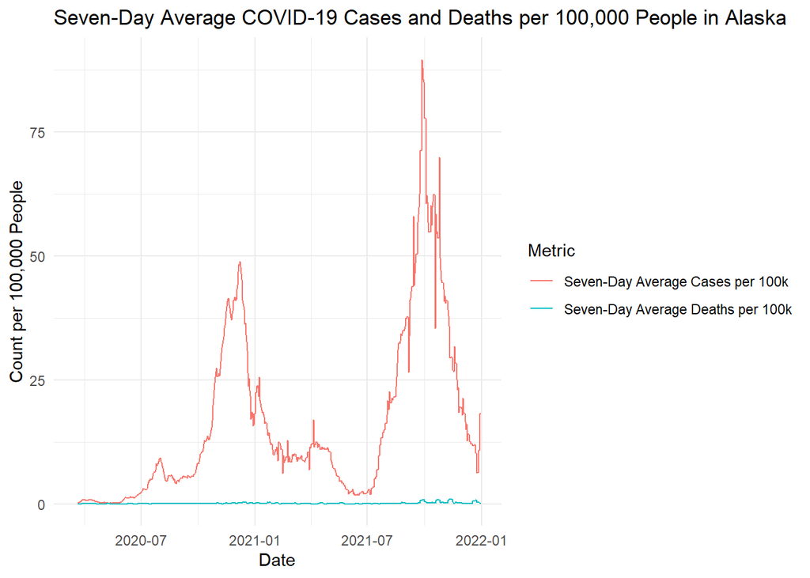

```r
# Create the visualization
ggplot(alaska_data, aes(x = date)) +
  geom_line(aes(y = cases_7_day, color = "Seven-Day Average Cases per 100k")) +
  geom_line(aes(y = deaths_7_day, color = "Seven-Day Average Deaths per 100k")) +
  labs(
    title = "Seven-Day Average COVID-19 Cases and Deaths per 100,000 People in Alaska",
    x = "Date",
    y = "Count per 100,000 People",
    color = "Metric"
  ) +
  theme_minimal() +
  scale_y_continuous(labels = scales::comma)
```

```r
# Your transformed data should look similar to the following tibble:
#
# A tibble: 656 × 9
#     state    date       total_deaths total_cases population deaths_per_100k cases_per_100k deaths_7_day  cases_7_day
#     <chr>    <date>            <dbl>    <dbl>      <dbl>         <dbl>          <dbl>        <dbl>         <dbl>
#  1 Colorado 2020-03-15            2      136      5784308        0.0346          2.35         NA            NA
#  2 Colorado 2020-03-16            2      161      5784308        0.0346          2.78         NA            NA
#  3 Colorado 2020-03-17            3      183      5784308        0.0519          3.16         NA            NA
#  4 Colorado 2020-03-18            3      216      5784308        0.0519          3.73         NA            NA
#  5 Colorado 2020-03-19            5      278      5784308        0.0864          4.81         NA            NA
#  6 Colorado 2020-03-20            5      364      5784308        0.0864          6.29         NA            NA
#  7 Colorado 2020-03-21            6      475      5784308        0.104           8.21         NA            NA
#  8 Colorado 2020-03-22            7      591      5784308        0.121           10.2       0.0123         1.12
#  9 Colorado 2020-03-23           10      721      5784308        0.173           12.5       0.0198         1.38
# 10 Colorado 2020-03-24           11      912      5784308        0.190           15.8       0.0198         1.80
# … with 646 more rows
```

– Communicate your methodology, results, and interpretation here –

Data Preparation -> Population Data -> Select State (Alaska) -> Normalization -> Visualization

The visualization displays the seven-day average of new COVID-19 cases and deaths per 100,000 people in Alaska over time. This approach normalizes the data by population size, allowing for a more accurate comparison and highlighting the trends in new cases and deaths.

By looking at the trends in this visualization, health officials can better understand the spread and impact of COVID-19 in Alaska. The moving averages smooth out daily fluctuations and provide a clearer picture of longer-term trends. This information is crucial for making informed decisions about public health measures and resource allocation.

##### Question 4

Using the same state, identify the top 5 counties in terms of deaths and cases per 100,000 people.

```r
# Using the same state as Question 2, filter your state and date range from the combined data set from Part 1 and summarize cases and deaths. Produce two lists arranged by deaths and cases. When transforming the data, be sure to include the "fips" column as you will need this to complete Question 5.


# Filter the data for Alaska and dates between March 15, 2020, and December 31, 2021
alaska_data <- us_counties_combined %>%
  filter(state == "Alaska" & date >= "2020-03-15" & date <= "2021-12-31")

# Summarize the total deaths and cases by county
county_totals <- alaska_data %>%
  group_by(county, fips) %>%
  summarise(
    total_deaths = sum(deaths, na.rm = TRUE),
    total_cases = sum(cases, na.rm = TRUE)
  )
# Convert fips to character in both datasets
county_totals <- county_totals %>%
  mutate(fips = as.character(fips))

us_population_estimates <- us_population_estimates %>%
  mutate(fips = as.character(fips))

# Ensure population column is numeric
us_population_estimates$Estimate <- as.numeric(us_population_estimates$Estimate)

# Summarize population by county (using fips)
county_population <- us_population_estimates %>%
  filter(STNAME == "Alaska") %>%
  group_by(fips) %>%
  summarise(total_population = sum(Estimate, na.rm = TRUE))

# Join the county_totals with county_population
county_totals <- county_totals %>%
  left_join(county_population, by = "fips")

# Calculate deaths and cases per 100,000 people
county_totals <- county_totals %>%
  mutate(
    deaths_per_100k = (total_deaths / total_population) * 100000,
    cases_per_100k = (total_cases / total_population) * 100000
  )

# Determine the top 5 counties by deaths per 100,000 people
top_5_deaths_per_100k <- county_totals %>%
  arrange(desc(deaths_per_100k)) %>%
  slice(1:5)

# Determine the top 5 counties by cases per 100,000 people
top_5_cases_per_100k <- county_totals %>%
  arrange(desc(cases_per_100k)) %>%
  slice(1:5)

# Output the results
print(top_5_deaths_per_100k)
```

```
## # A tibble: 28 × 7
## # Groups:   county [28]
##    county        fips  total_deaths total_cases total_population deaths_per_100k
##    <chr>         <chr>        <dbl>       <dbl>            <dbl>           <dbl>
##  1 Aleutians Ea… 02013          870      134048               NA              NA
##  2 Aleutians We… 02016           54      279979               NA              NA
##  3 Anchorage     02020        88208    15181403               NA              NA
##  4 Bethel Censu… 02050         8342     1731124               NA              NA
##  5 Bristol Bay … 02997           38      119966               NA              NA
##  6 Denali Borou… 02068           99       58464               NA              NA
##  7 Dillingham C… 02070         1208      158283               NA              NA
##  8 Fairbanks No… 02090        21404     3871383               NA              NA
##  9 Haines Borou… 02100           65       35867               NA              NA
## 10 Juneau City … 02110         2127      867358               NA              NA
## # ℹ 18 more rows
## # ℹ 1 more variable: cases_per_100k <dbl>
```

```r
print(top_5_cases_per_100k)
```

```
## # A tibble: 28 × 7
## # Groups:   county [28]
##    county        fips  total_deaths total_cases total_population deaths_per_100k
##    <chr>         <chr>        <dbl>       <dbl>            <dbl>           <dbl>
##  1 Aleutians Ea… 02013          870      134048               NA              NA
##  2 Aleutians We… 02016           54      279979               NA              NA
##  3 Anchorage     02020        88208    15181403               NA              NA
##  4 Bethel Censu… 02050         8342     1731124               NA              NA
##  5 Bristol Bay … 02997           38      119966               NA              NA
##  6 Denali Borou… 02068           99       58464               NA              NA
##  7 Dillingham C… 02070         1208      158283               NA              NA
##  8 Fairbanks No… 02090        21404     3871383               NA              NA
##  9 Haines Borou… 02100           65       35867               NA              NA
## 10 Juneau City … 02110         2127      867358               NA              NA
## # ℹ 18 more rows
## # ℹ 1 more variable: cases_per_100k <dbl>
```

```r
# Your transformed data should be similar to the following tibbles:
#
# Arranged by deaths:
# A tibble: 64 × 4
#     county       date       fips    total_deaths   total_cases
#     <chr>       <date>      <chr>       <dbl>         <dbl>
#  1 El Paso    2021-12-20    08041       1355         119772
#  2 Denver     2021-12-20    08031       1065         106747
#  3 Jefferson  2021-12-20    08059       1061         76732
#  4 Adams      2021-12-20    08001       1057         90476
#  5 Arapahoe   2021-12-20    08005       1046         95769
#  6 Pueblo     2021-12-20    08101        643         30739
#  7 Weld       2021-12-20    08123        569         55599
#  8 Mesa       2021-12-20    08077        445         29542
#  9 Larimer    2021-12-20    08069        393         47444
# 10 Douglas    2021-12-20    08035        361         48740
# … with 54 more rows
#
#
# Arranged by cases:
# A tibble: 64 × 4
#     county       date       fips   total_deaths   total_cases
#     <chr>       <date>      <chr>     <dbl>         <dbl>
#  1 El Paso    2021-12-20    08041     1355         119772
#  2 Denver     2021-12-20    08031     1065         106747
#  3 Arapahoe   2021-12-20    08005     1046          95769
#  4 Adams      2021-12-20    08001     1057          90476
#  5 Jefferson  2021-12-20    08059     1061          76732
#  6 Weld       2021-12-20    08123      569          55599
#  7 Douglas    2021-12-20    08035      361          48740
#  8 Larimer    2021-12-20    08069      393          47444
#  9 Boulder    2021-12-20    08013      323          36754
# 10 Pueblo     2021-12-20    08101      643          30739
# … with 54 more rows
```

– Communicate your methodology, results, and interpretation here –

Data Preparation -> Summarization -> Population Data -> Normalization -> Sorting and Filtering

##### Question 5

Modify the code below for the map projection to plot county-level deaths and cases per 100,000 people for your state.

[figure not shown]

```r
# Map visualization for deaths per 100,000 people
plot_usmap(regions = "county", include = "AK", data = top_5_deaths_per_100k, values = "deaths_per_100k", color = "red") +
  scale_fill_continuous(low = "white", high = "red", name = "Deaths per 100,000") +
  labs(title = "COVID-19 Deaths per 100,000 People in Alaska Counties") +
  theme(legend.position = "right")
```

[figure not shown]

```r
# Map visualization for deaths per 100,000 people
plot_usmap(regions = "county", include = "AK", data = top_5_cases_per_100k, values = "cases_per_100k", color = "red") +
  scale_fill_continuous(low = "white", high = "red", name = "Cases per 100,000") +
  labs(title = "COVID-19 Cases per 100,000 People in Alaska Counties") +
  theme(legend.position = "right")
```

```r
# Copy and modify the code below for your state.
#
# plot_usmap arguments:
#   regions: can be one of ("states", "state", "counties", "county"). The default is "states"
#   include: The regions to include in the resulting map. If regions is "states"/"state", the value can be either a state name, abbreviation or FIPS code. For counties, the FIPS must be provided as there can be multiple counties with the same name.
#   data: values to plot on the map
#   values: the name of the column that contains the values to be associated with a given region.
#   color: the map outline color.
#
# Reference the plot_usmap documentation for further information using ?plot_usmap

#plot_usmap(regions = "county", include="CO", data = colorado_county, values = "total_deaths", color = "blue") +  scale_fill_continuous(low = "white", high = "blue", name = "Deaths per 100,000")
```

– Communicate your methodology, results, and interpretation here –

##### Question 6

Finally, select three other states and calculate the seven-day averages for new deaths and cases per 100,000 people for between March 15, 2020, and December 31, 2021.

```r
# Combine the datasets
us_counties_combined <- bind_rows(us_counties_2020, us_counties_2021, us_counties_2022)

# Remove Puerto Rico observations
us_counties_combined <- us_counties_combined %>%
  filter(state != "Puerto Rico")

# Filter the data for dates between March 15, 2020, and December 31, 2021
us_counties_filtered <- us_counties_combined %>%
  filter(date >= "2020-03-15" & date <= "2021-12-31")

# List of states to analyze
states <- c("Alabama", "Arizona", "Arkansas")

# Summarize the total deaths and cases by state
state_totals <- us_counties_filtered %>%
  filter(state %in% states) %>%
  group_by(state, date) %>%
  summarise(
    total_deaths = sum(deaths, na.rm = TRUE),
    total_cases = sum(cases, na.rm = TRUE)
  ) %>%
  ungroup()
# Summarize population by state
state_population <- us_population_estimates %>%
  filter(STNAME %in% states) %>%
  group_by(STNAME) %>%
  summarise(total_population = sum(Estimate, na.rm = TRUE)) %>%
  rename(state = STNAME)

# Join the state_totals with state_population
state_totals <- state_totals %>%
  left_join(state_population, by = "state")

# Calculate new cases and deaths each day and their 7-day averages per 100,000 people
state_totals <- state_totals %>%
  group_by(state) %>%
  mutate(
    new_deaths = total_deaths - lag(total_deaths, default = 0),
    new_cases = total_cases - lag(total_cases, default = 0),
    deaths_per_100k = (new_deaths / total_population) * 100000,
    cases_per_100k = (new_cases / total_population) * 100000,
    deaths_7_day = rollmean(deaths_per_100k, 7, fill = NA, align = "right"),
    cases_7_day = rollmean(cases_per_100k, 7, fill = NA, align = "right")
  ) %>%
  ungroup()

# Display the first few rows of the tibble
print(state_totals)
```

```
## # A tibble: 1,971 × 11
##    state   date       total_deaths total_cases total_population new_deaths
##    <chr>   <date>            <dbl>       <dbl>            <dbl>      <dbl>
##  1 Alabama 2020-03-15            0          23         10064680          0
##  2 Alabama 2020-03-16            0          29         10064680          0
##  3 Alabama 2020-03-17            0          39         10064680          0
##  4 Alabama 2020-03-18            0          51         10064680          0
##  5 Alabama 2020-03-19            0          78         10064680          0
##  6 Alabama 2020-03-20            0         106         10064680          0
##  7 Alabama 2020-03-21            0         131         10064680          0
##  8 Alabama 2020-03-22            0         157         10064680          0
##  9 Alabama 2020-03-23            0         196         10064680          0
## 10 Alabama 2020-03-24            0         242         10064680          0
## # ℹ 1,961 more rows
## # ℹ 5 more variables: new_cases <dbl>, deaths_per_100k <dbl>,
## #   cases_per_100k <dbl>, deaths_7_day <dbl>, cases_7_day <dbl>
```

– Communicate your methodology, results, and interpretation here –

Data Preparation -> Population Data -> Normalization

The resulting data frame state_totals contains the seven-day averages for new cases and deaths per 100,000 people for Alabama, Arizona, and Arkansas. This data provides a clear view of how the COVID-19 situation evolved in each state, adjusted for population size.

##### Question 7

Create a visualization comparing the seven-day averages for new deaths and cases per 100,000 people for the four states you selected.

```r
# Combine the datasets
us_counties_combined <- bind_rows(us_counties_2020, us_counties_2021, us_counties_2022)

# Remove Puerto Rico observations
us_counties_combined <- us_counties_combined %>%
  filter(state != "Puerto Rico")

# Filter the data for dates between March 15, 2020, and December 31, 2021
us_counties_filtered <- us_counties_combined %>%
  filter(date >= "2020-03-15" & date <= "2021-12-31")

# List of states to analyze
states <- c("Alabama", "Arizona", "Arkansas", "Alaska")

# Summarize the total deaths and cases by state
state_totals <- us_counties_filtered %>%
  filter(state %in% states) %>%
  group_by(state, date) %>%
  summarise(
    total_deaths = sum(deaths, na.rm = TRUE),
    total_cases = sum(cases, na.rm = TRUE)
  ) %>%
  ungroup()
```

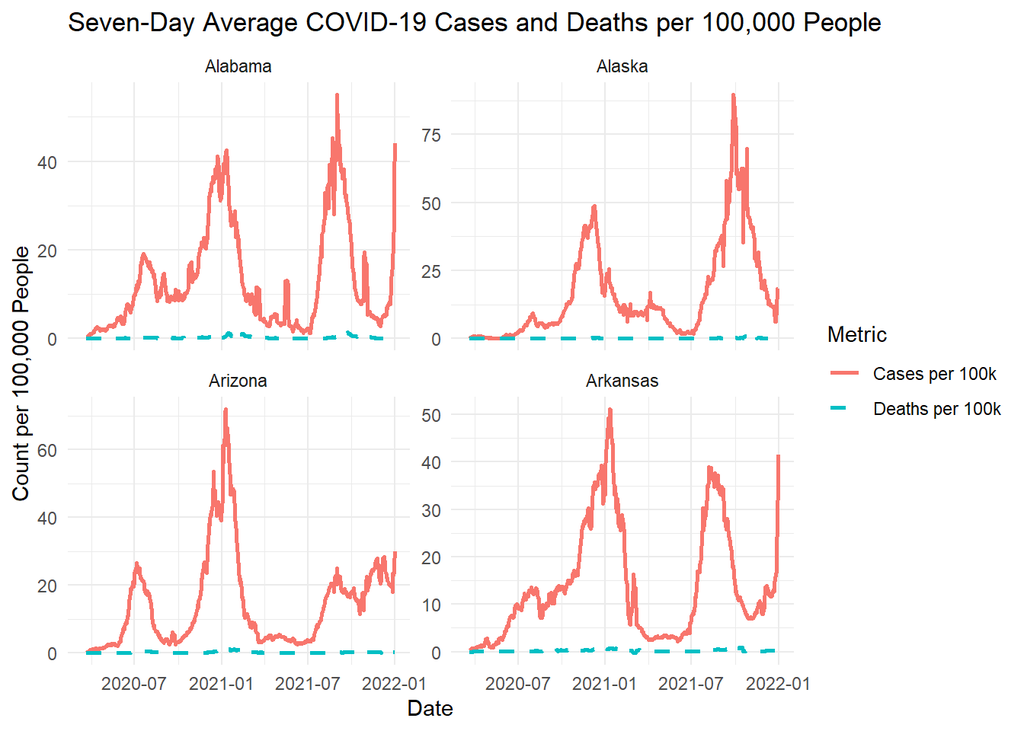

```r
# Summarize population by state
state_population <- us_population_estimates %>%
  filter(STNAME %in% states) %>%
  group_by(STNAME) %>%
  summarise(total_population = sum(Estimate, na.rm = TRUE)) %>%
  rename(state = STNAME)

# Join the state_totals with state_population
state_totals <- state_totals %>%
  left_join(state_population, by = "state")

# Calculate new cases and deaths each day and their 7-day averages per 100,000 people
state_totals <- state_totals %>%
  group_by(state) %>%
  mutate(
    new_deaths = total_deaths - lag(total_deaths, default = 0),
    new_cases = total_cases - lag(total_cases, default = 0),
    deaths_per_100k = (new_deaths / total_population) * 100000,
    cases_per_100k = (new_cases / total_population) * 100000,
    deaths_7_day = rollmean(deaths_per_100k, 7, fill = NA, align = "right"),
    cases_7_day = rollmean(cases_per_100k, 7, fill = NA, align = "right")
  ) %>%
  ungroup()

# Visualization
ggplot(state_totals, aes(x = date)) +
  geom_line(aes(y = cases_7_day, color = "Cases per 100k"), size = 1) +
  geom_line(aes(y = deaths_7_day, color = "Deaths per 100k"), size = 1, linetype = "dashed") +
  facet_wrap(~ state, scales = "free_y") +
  labs(
    title = "Seven-Day Average COVID-19 Cases and Deaths per 100,000 People",
    x = "Date",
    y = "Count per 100,000 People",
    color = "Metric"
  ) +
  theme_minimal() +
  scale_y_continuous(labels = scales::comma)
```

– Communicate your methodology, results, and interpretation here –

Data Preparation -> Visualization

The visualization shows the seven-day average of new COVID-19 cases and deaths per 100,000 people for Alabama, Alaska, Arizona, and Arkansas. The solid lines represent the cases per 100,000 people, and the dashed lines represent the deaths per 100,000 people.

By comparing these trends, we can see how the pandemic affected each state over time. This information is crucial for understanding regional differences in the spread and impact of COVID-19 and can inform public health strategies and resource allocation.

#### Part 3 - Global Comparison

```r
# Import global COVID-19 statistics aggregated by the Center for Systems Science and Engineering (CSSE) at Johns Hopkins University.
# Import global population estimates from the World Bank.

csse_global_deaths <- read_csv("time_series_covid19_deaths_global.csv")
csse_global_cases <- read_csv("time_series_covid19_confirmed_global.csv")
csse_us_deaths <- read_csv("time_series_covid19_deaths_US.csv")
csse_us_cases <- read_csv("time_series_covid19_confirmed_US.csv")
global_population_estimates <- read_csv("global_population_estimates.csv")
```

##### Question 1

Using the state you selected in Part 2 Question 2 compare the daily number of cases and deaths reported from the CSSE and NY Times.

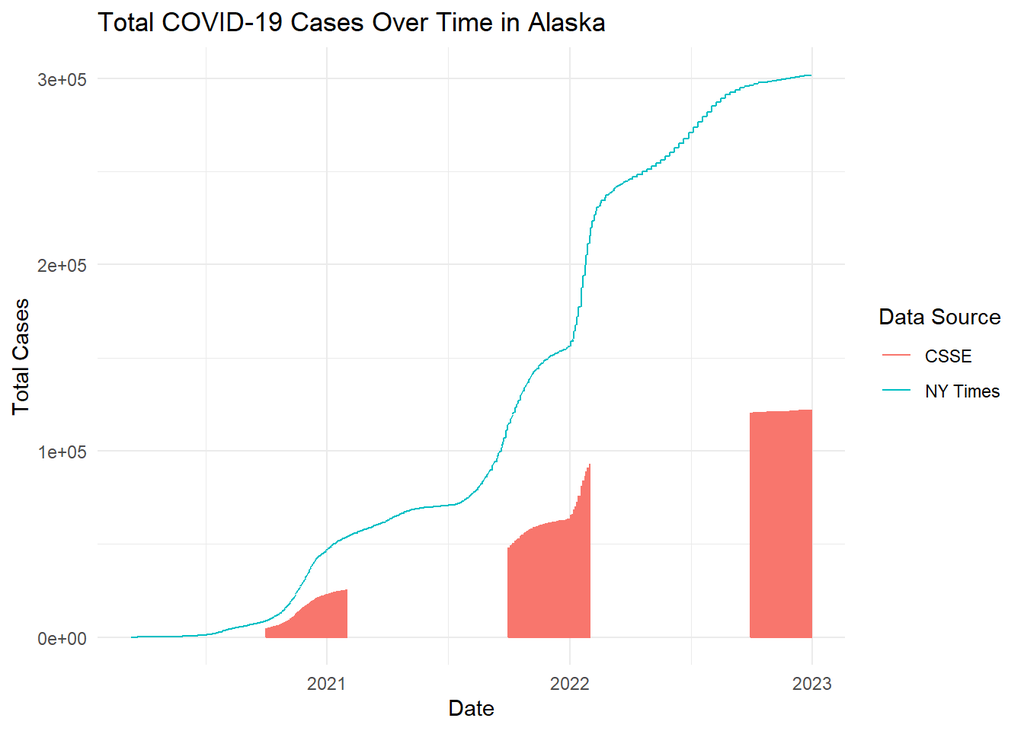

```r
# To compare your state data between the two data sets, you will first need to tidy the US CSSE death and cases data.
# Hint: Review the documentation for pivot_longer().

# Filter CSSE data for Alaska and pivot longer to tidy format
csse_cases_alaska <- csse_us_cases %>%
  filter(Province_State == "Alaska") %>%
  select(-c(UID, iso2, iso3, code3, FIPS, Admin2, Country_Region, Lat, Long_, Combined_Key)) %>%
  pivot_longer(cols = starts_with("1"), names_to = "date", values_to = "total_cases") %>%
  mutate(date = mdy(date))

csse_deaths_alaska <- csse_us_deaths %>%
  filter(Province_State == "Alaska") %>%
  select(-c(UID, iso2, iso3, code3, FIPS, Admin2, Country_Region, Lat, Long_, Combined_Key)) %>%
  pivot_longer(cols = starts_with("1"), names_to = "date", values_to = "total_deaths") %>%
  mutate(date = mdy(date))

# Join the CSSE cases and deaths data
csse_alaska <- csse_cases_alaska %>%
  left_join(csse_deaths_alaska, by = c("Province_State", "date"))



# Once you have tidied your data, join the two CSSE US data sets to include cases and deaths in one table.

# Read in the NY Times data
#us_counties_2020 <- read_csv("us-counties-2020.csv")
#us_counties_2021 <- read_csv("us-counties-2021.csv")
#us_counties_2022 <- read_csv("us-counties-2022.csv")

# Combine the NY Times datasets
us_counties_combined <- bind_rows(us_counties_2020, us_counties_2021, us_counties_2022)

# Filter the NY Times data for Alaska
nytimes_alaska <- us_counties_combined %>%
  filter(state == "Alaska") %>%
  group_by(date) %>%
  summarise(
    total_cases = sum(cases, na.rm = TRUE),
    total_deaths = sum(deaths, na.rm = TRUE)
  )

# Join NY Times and CSSE data
comparison_data <- nytimes_alaska %>%
  rename(nytimes_total_cases = total_cases, nytimes_total_deaths = total_deaths) %>%
  left_join(csse_alaska, by = "date") %>%
  rename(csse_total_cases = total_cases, csse_total_deaths = total_deaths)


# Finally, create two visualizations with one plotting the CSSE and NY Times cases and the other plotting the CSEE and NY Times deaths.

# Visualization for cases
ggplot(comparison_data, aes(x = date)) +
  geom_line(aes(y = nytimes_total_cases, color = "NY Times")) +
  geom_line(aes(y = csse_total_cases, color = "CSSE")) +
  labs(
    title = "Total COVID-19 Cases Over Time in Alaska",
    x = "Date",
    y = "Total Cases",
    color = "Data Source"
  ) +
  theme_minimal()
```

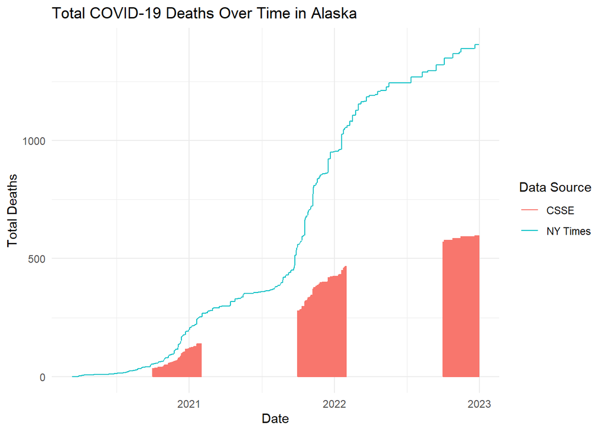

```r
# Visualization for deaths
ggplot(comparison_data, aes(x = date)) +
  geom_line(aes(y = nytimes_total_deaths, color = "NY Times")) +
  geom_line(aes(y = csse_total_deaths, color = "CSSE")) +
  labs(
    title = "Total COVID-19 Deaths Over Time in Alaska",
    x = "Date",
    y = "Total Deaths",
    color = "Data Source"
  ) +
  theme_minimal()
```

```r
# Your tidied CSSE data for your selected state should look similar to the following tibble:
#
# A tibble: 43,362 × 6
#     fips  county  state        date      cases  deaths
#     <dbl> <chr>   <chr>       <date>     <dbl>  <dbl>
#  1  8001  Adams  Colorado   2020-03-15     6      0
#  2  8001  Adams  Colorado   2020-03-16     8      0
#  3  8001  Adams  Colorado   2020-03-17    10      0
#  4  8001  Adams  Colorado   2020-03-18    10      0
#  5  8001  Adams  Colorado   2020-03-19    10      0
#  6  8001  Adams  Colorado   2020-03-20    12      0
#  7  8001  Adams  Colorado   2020-03-21    14      0
#  8  8001  Adams  Colorado   2020-03-22    18      0
#  9  8001  Adams  Colorado   2020-03-23    25      0
# 10  8001  Adams  Colorado   2020-03-24    27      0
# … with 43,352 more rows
```

– Communicate your methodology, results, and interpretation here –

Import and Tidy CSSE Data -> Join CSSE Cases and Deaths -> Tidy NY Times Data -> Join NY Times and CSSE Data -> Visualization

The visualizations show the total COVID-19 cases and deaths over time in Alaska, comparing data reported by NY Times and CSSE. By plotting the data from both sources, we can verify their consistency and investigate any discrepancies.

##### Question 2

Now that you have verified the data reported from the CSSE and NY Times are similar, combine the global and US CSSE data sets and identify the top 10 countries in terms of deaths and cases per 100,000 people between March 15, 2020, and December 31, 2021.

```r
# First, combine and tidy the CSSE death and cases data sets. You may wish to keep the two sets separate.

# Transform global cases data
global_cases <- csse_global_cases %>%
  pivot_longer(cols = starts_with("1"), names_to = "date", values_to = "total_cases") %>%
  mutate(date = mdy(date)) %>%
  select(`Country/Region`, date, total_cases)

# Transform global deaths data
global_deaths <- csse_global_deaths %>%
  pivot_longer(cols = starts_with("1"), names_to = "date", values_to = "total_deaths") %>%
  mutate(date = mdy(date)) %>%
  select(`Country/Region`, date, total_deaths)

# Transform US cases data
us_cases <- csse_us_cases %>%
  pivot_longer(cols = starts_with("1"), names_to = "date", values_to = "total_cases") %>%
  mutate(date = mdy(date)) %>%
  select(Province_State, `Country_Region` = `Country_Region`, date, total_cases)

# Transform US deaths data
us_deaths <- csse_us_deaths %>%
  pivot_longer(cols = starts_with("1"), names_to = "date", values_to = "total_deaths") %>%
  mutate(date = mdy(date)) %>%
  select(Province_State, `Country_Region` = `Country_Region`, date, total_deaths)

# Combine global and US cases
all_cases <- bind_rows(global_cases, us_cases)

# Combine global and US deaths
all_deaths <- bind_rows(global_deaths, us_deaths)

# Then, tidy the global population estimates. While tidying your data, remember to include columns that you will be able to use when joining the COVID-19 data.

# Tidy the population data
tidy_population <- global_population_estimates %>%
  rename(`Country/Region` = `Country Name`, population = `2021 [YR2021]`) %>%
  select(`Country/Region`, population) %>%
  mutate(population = as.numeric(population))




# You will notice that the population estimates data does not include every country reported in the CSSE data. When calculating statistics per 100,000 people, you will need to filter the CSSE data to only include countries that you have population estimates for.

# Summarize cases and deaths by country
summary_cases <- all_cases %>%
  filter(date >= "2020-03-15" & date <= "2021-12-31") %>%
  group_by(`Country/Region`) %>%
  summarise(total_cases = sum(total_cases, na.rm = TRUE))

summary_deaths <- all_deaths %>%
  filter(date >= "2020-03-15" & date <= "2021-12-31") %>%
  group_by(`Country/Region`) %>%
  summarise(total_deaths = sum(total_deaths, na.rm = TRUE))

# Join with population estimates
cases_with_population <- summary_cases %>%
  inner_join(tidy_population, by = "Country/Region") %>%
  mutate(cases_per_100k = (total_cases / population) * 100000)

deaths_with_population <- summary_deaths %>%
  inner_join(tidy_population, by = "Country/Region") %>%
  mutate(deaths_per_100k = (total_deaths / population) * 100000)

# Filter to include only countries with population estimates
valid_cases <- cases_with_population %>%
  filter(!is.na(population))

valid_deaths <- deaths_with_population %>%
  filter(!is.na(population))

# Top 10 countries by cases per 100,000 people
top_10_cases_per_100k <- valid_cases %>%
  arrange(desc(cases_per_100k)) %>%
  slice(1:10)

# Top 10 countries by deaths per 100,000 people
top_10_deaths_per_100k <- valid_deaths %>%
  arrange(desc(deaths_per_100k)) %>%
  slice(1:10)

# Output the results
print(top_10_cases_per_100k)
```

```
## # A tibble: 10 × 4
##    `Country/Region` total_cases population cases_per_100k
##    <chr>                  <dbl>      <dbl>          <dbl>
##  1 Andorra              2374138      77000       3083296.
##  2 Montenegro          18129027     621000       2919328.
##  3 Georgia             88580814    3712000       2386337.
##  4 San Marino            764709      34000       2249144.
##  5 Seychelles           2142979      99000       2164625.
##  6 Slovenia            44604578    2101000       2123017.
##  7 Bahrain             36247727    1748000       2073669.
##  8 Serbia             132407349    6863000       1929293.
##  9 Luxembourg          11951812     638000       1873325.
## 10 Israel             169986043    9357000       1816672.
```

```r
print(top_10_deaths_per_100k)
```

```
## # A tibble: 10 × 4
##    `Country/Region`       total_deaths population deaths_per_100k
##    <chr>                         <dbl>      <dbl>           <dbl>
##  1 Peru                       29585844   33359000          88689.
##  2 Bosnia and Herzegovina      1444655    3263000          44274.
##  3 San Marino                    14747      34000          43374.
##  4 North Macedonia              893778    2072000          43136.
##  5 Bulgaria                    2965646    6882000          43093.
##  6 Montenegro                   262789     621000          42317.
##  7 Moldova                     1065117    2614000          40747.
##  8 Hungary                     3772729    9721000          38810.
##  9 United Kingdom             25960104   67503000          38458.
## 10 Belgium                     4406995   11579000          38060.
```

– Communicate your methodology, results, and interpretation here –

Combine and Tidy Data -> Tidy Population Estimates -> Calculate Statistics -> Filter Data -> Identify Top 10 Countries

The results will show the top 10 countries in terms of COVID-19 cases and deaths per 100,000 people between March 15, 2020, and December 31, 2021. This analysis helps to understand which countries were most affected by the pandemic relative to their population size. It provides insights into the global impact of COVID-19 and helps identify regions that may require more attention and resources.

##### Question 3

Construct a visualization plotting the 10 countries in terms of deaths and cases per 100,000 people between March 15, 2020, and December 31, 2021. In designing your visualization keep the number of data you will be plotting in mind. You may wish to create two separate visualizations, one for deaths and another for cases.

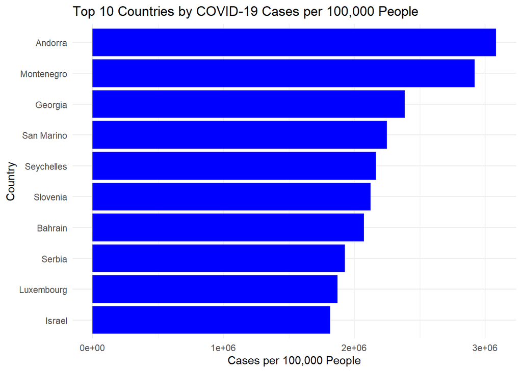

```r
# Visualization for cases per 100,000 people
ggplot(top_10_cases_per_100k, aes(x = reorder(`Country/Region`, cases_per_100k), y = cases_per_100k)) +
  geom_bar(stat = "identity", fill = "blue") +
  coord_flip() +
  labs(
    title = "Top 10 Countries by COVID-19 Cases per 100,000 People",
    x = "Country",
    y = "Cases per 100,000 People"
  ) +
  theme_minimal()
```

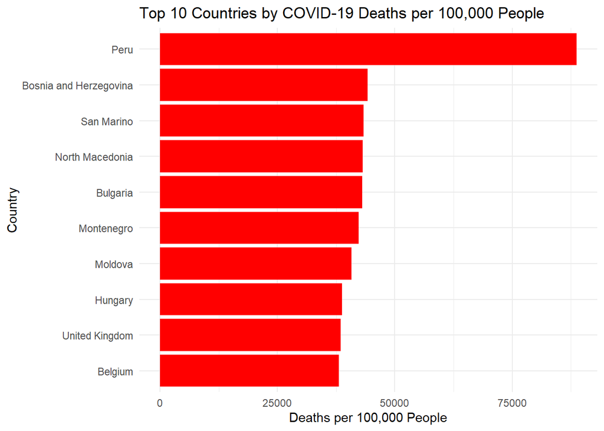

```r
# Visualization for deaths per 100,000 people
ggplot(top_10_deaths_per_100k, aes(x = reorder(`Country/Region`, deaths_per_100k), y = deaths_per_100k)) +
  geom_bar(stat = "identity", fill = "red") +
  coord_flip() +
  labs(
    title = "Top 10 Countries by COVID-19 Deaths per 100,000 People",
    x = "Country",
    y = "Deaths per 100,000 People"
  ) +
  theme_minimal()
```

– Communicate your methodology, results, and interpretation here –

Same as Q2, add in Visualize Data.

The visualizations show the top 10 countries in terms of COVID-19 cases and deaths per 100,000 people between March 15, 2020, and December 31, 2021. These visualizations provide insights into which countries were most affected by the pandemic relative to their population size. This information is useful for understanding the global impact of COVID-19 and identifying regions that may require more attention and resources.

##### Question 4

Finally, select four countries from one continent and create visualizations for the daily number of confirmed cases per 100,000 and the daily number of deaths per 100,000 people between March 15, 2020, and December 31, 2021.

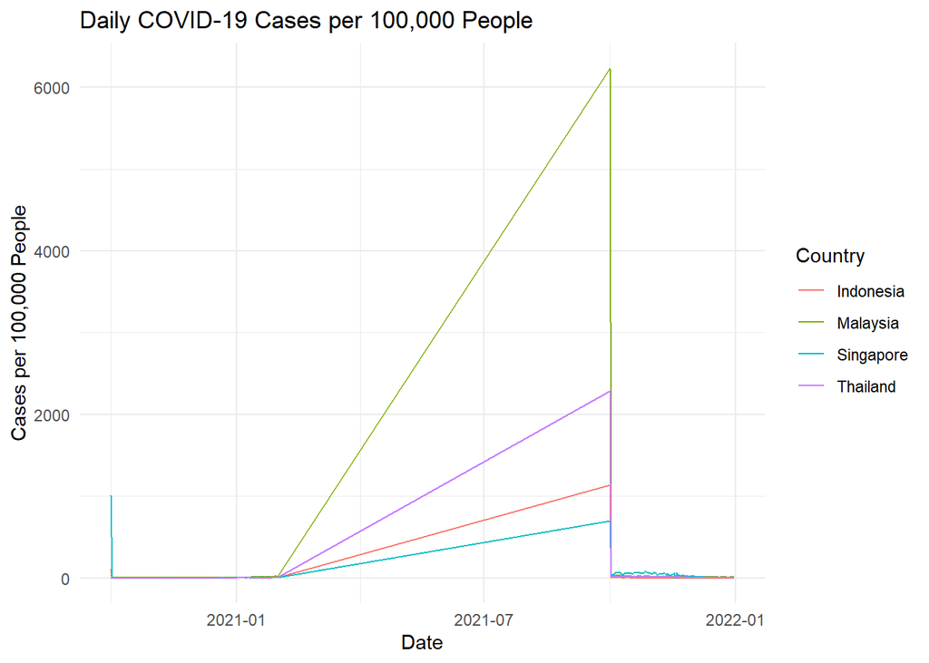

```r
# Filter data for the selected countries
selected_countries <- c("Indonesia", "Malaysia", "Singapore", "Thailand")

# Transform global cases data
global_cases <- csse_global_cases %>%
  filter(`Country/Region` %in% selected_countries) %>%
  pivot_longer(cols = starts_with("1"), names_to = "date", values_to = "total_cases") %>%
  mutate(date = mdy(date)) %>%
  select(`Country/Region`, date, total_cases)

# Transform global deaths data
global_deaths <- csse_global_deaths %>%
  filter(`Country/Region` %in% selected_countries) %>%
  pivot_longer(cols = starts_with("1"), names_to = "date", values_to = "total_deaths") %>%
  mutate(date = mdy(date)) %>%
  select(`Country/Region`, date, total_deaths)

# Tidy the population data
tidy_population <- global_population_estimates %>%
  rename(`Country/Region` = `Country Name`, population = `2021 [YR2021]`) %>%
  select(`Country/Region`, population) %>%
  mutate(population = as.numeric(population))

# Join cases and deaths data with population estimates
cases_with_population <- global_cases %>%
  inner_join(tidy_population, by = "Country/Region")

deaths_with_population <- global_deaths %>%
  inner_join(tidy_population, by = "Country/Region")

# Calculate daily new cases and deaths
cases_with_population <- cases_with_population %>%
  group_by(`Country/Region`) %>%
  arrange(date) %>%
  mutate(new_cases = total_cases - lag(total_cases, default = 0)) %>%
  mutate(cases_per_100k = (new_cases / population) * 100000)

deaths_with_population <- deaths_with_population %>%
  group_by(`Country/Region`) %>%
  arrange(date) %>%
  mutate(new_deaths = total_deaths - lag(total_deaths, default = 0)) %>%
  mutate(deaths_per_100k = (new_deaths / population) * 100000)

# Filter for the date range between March 15, 2020, and December 31, 2021
cases_with_population <- cases_with_population %>%
  filter(date >= "2020-03-15" & date <= "2021-12-31")

deaths_with_population <- deaths_with_population %>%
  filter(date >= "2020-03-15" & date <= "2021-12-31")

# Visualizations
# Cases per 100,000 people
ggplot(cases_with_population, aes(x = date, y = cases_per_100k, color = `Country/Region`)) +
  geom_line() +
  labs(
    title = "Daily COVID-19 Cases per 100,000 People",
    x = "Date",
    y = "Cases per 100,000 People",
    color = "Country"
  ) +
  theme_minimal()
```

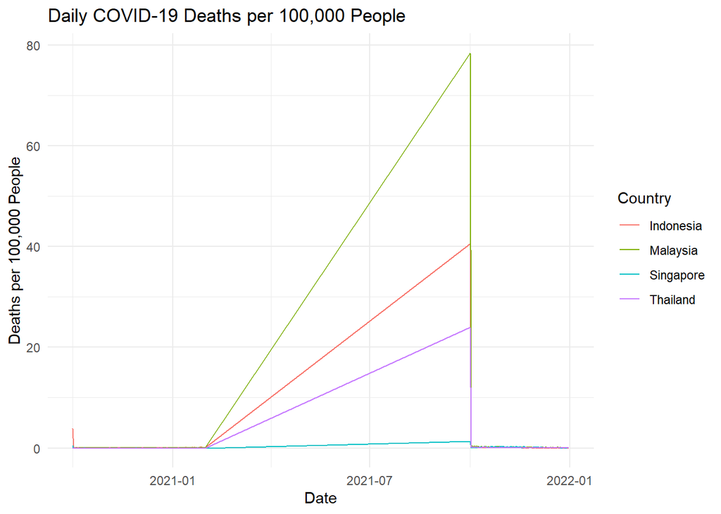

```r
# Deaths per 100,000 people
ggplot(deaths_with_population, aes(x = date, y = deaths_per_100k, color = `Country/Region`)) +
  geom_line() +
  labs(
    title = "Daily COVID-19 Deaths per 100,000 People",
    x = "Date",
    y = "Deaths per 100,000 People",
    color = "Country"
  ) +
  theme_minimal()
```

– Communicate your methodology, results, and interpretation here –

Data Preparation -> Population Data -> Calculate Daily Statistics -> Visualization